# Code

# Phần 2: Phân tích dữ liệu

## Câu 1: Lượng Cholesterol cao ảnh hưởng như thế nào đến nguy cơ mắc bệnh tim?

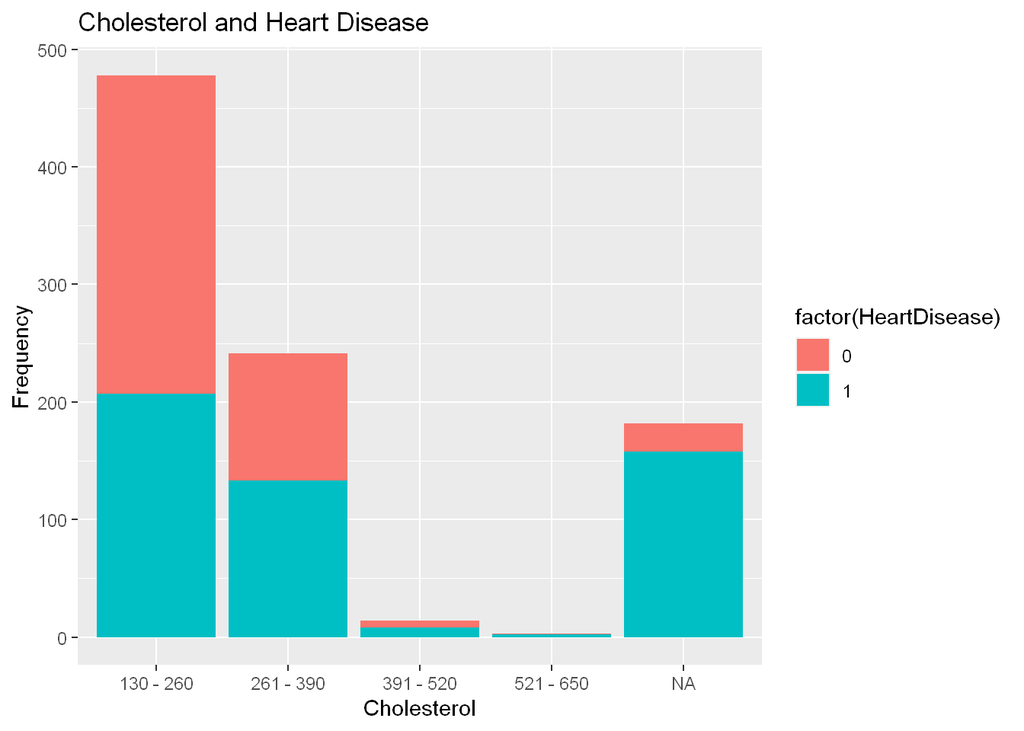

```r
cut_cholesterol <- split(data, cut(data$Cholesterol, c(130, 260, 390, 520, 650), include.lowest=TRUE))
Chol130_260 <- sum(cut_cholesterol[[1]]$HeartDisease==1)/nrow(cut_cholesterol[[1]]) #130-260
Chol261_390 <- sum(cut_cholesterol[[2]]$HeartDisease==1)/nrow(cut_cholesterol[[2]]) #261-390
Chol391_520 <- sum(cut_cholesterol[[3]]$HeartDisease==1)/nrow(cut_cholesterol[[3]]) #390-520
Chol521_650 <- sum(cut_cholesterol[[4]]$HeartDisease==1)/nrow(cut_cholesterol[[4]]) #520-650

dfc <- data
dfc$CholGroup[dfc$Cholesterol > 130 & dfc$Cholesterol <= 260] <- '130 - 260'
dfc$CholGroup[dfc$Cholesterol > 260 & dfc$Cholesterol <= 390] <- '261 - 390'
dfc$CholGroup[dfc$Cholesterol > 390 & dfc$Cholesterol <= 520] <- '391 - 520'
dfc$CholGroup[dfc$Cholesterol > 520 & dfc$Cholesterol <= 650] <- '521 - 650'

ggplot(dfc, aes(x = CholGroup, fill = factor(HeartDisease))) +
  geom_bar() +
  labs(title = "Cholesterol and Heart Disease",
       x = "Cholesterol",
       y = "Frequency")
```

```r
cat("Nguoi co luong Cholesterol tu 130 - 260 co ", round(Chol130_260*100, 2), "% kha nang mac benh tim\n", sep = "")
```

```
## Nguoi co luong Cholesterol tu 130 - 260 co 43.31% kha nang mac benh tim
```

```r
cat("Nguoi co luong Cholesterol tu 261 - 390 co ", round(Chol261_390*100, 2), "% kha nang mac benh tim\n", sep = "")
```

```
## Nguoi co luong Cholesterol tu 261 - 390 co 55.19% kha nang mac benh tim
```

```r
cat("Nguoi co luong Cholesterol tu 391 - 520 co ", round(Chol391_520*100, 2), "% kha nang mac benh tim\n", sep = "")
```

```
## Nguoi co luong Cholesterol tu 391 - 520 co 57.14% kha nang mac benh tim
```

```r
cat("Nguoi co luong Cholesterol tu 521 - 650 co ", round(Chol521_650*100, 2), "% kha nang mac benh tim\n", sep = "")
```

```
## Nguoi co luong Cholesterol tu 521 - 650 co 66.67% kha nang mac benh tim
```

Qua tỷ lệ ở trên ta có thể thấy được rằng người có lượng Cholesteol càng lớn thì khả năng mắc bệnh tim càng cao.

## Câu 2: Nam giới có nguy cơ mắc bệnh tim cao hơn nữ giới hay không?

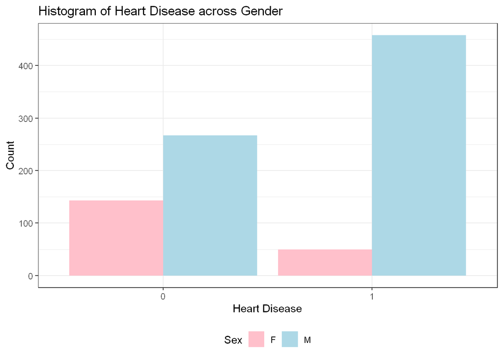

```r
ggplot(data, aes(x = factor(HeartDisease), fill = Sex)) +
  geom_bar(stat = "count", position="dodge") +
  theme_bw() +
  labs(title = "Histogram of Heart Disease across Gender",
       x="Heart Disease", y="Count") +
  scale_fill_manual(values = c("pink", "lightblue")) +
  theme(legend.position = "bottom")
```

```r
MaleHD <- subset(data, data$Sex=="M")
MaleHeart <- sum(MaleHD$HeartDisease==1) / nrow(MaleHD)

FemaleHD<-subset(data, data$Sex=="F")
FemaleHeart <- sum(FemaleHD$HeartDisease==1) / nrow(FemaleHD)
```

- Số lượng nam giới bị bệnh tim cao hơn nam không bị bệnh tim, số lượng nữ giới bị bệnh tim thấp hơn số lượng nữ không bị bệnh tim.

### Sử dụng kiểm định ý nghĩa thống kê:

- H0: Giới tính không ảnh hưởng đến khá năng mắc bệnh tim
- H1: Giới tính nam có khả năng mắc bệnh tim cao hơn nữ

```r
t.test(MaleHD$HeartDisease,FemaleHD$HeartDisease,alternative = "two.sided", conf.level = 0.99)
```

```
##
##  Welch Two Sample t-test
##
## data:  MaleHD$HeartDisease and FemaleHD$HeartDisease
## t = 10.253, df = 326.32, p-value < 2.2e-16
## alternative hypothesis: true difference in means is not equal to 0
## 99 percent confidence interval:
##  0.2784831 0.4668304
## sample estimates:
## mean of x mean of y
## 0.6317241 0.2590674
```

- **Nhận xét:**
  - Vì giá trị p < 0.05 nên có ý nghĩa thống kê, ta bác bỏ H0 và chấp nhận H1.
  - Nam giới có nguy cơ mắc bệnh tim cao hơn từ 28% - 47% so với nữ.
  - Tỷ lệ nam giới bị bệnh tim trong tập dữ liệu chiếm 63.17% và nữ giới bị bệnh tim chiếm 25.9%